# **Shameless (UK TV Series)**

*Shameless* is a **British comedy series** set in **Manchester** on the fictional **Chatsworth council estate**, created and partially written by **Paul Abbott**, who is also the programme's **executive producer**.

Produced by **Company Pictures** for **Channel 4**, the series aired from **13 January 2004** to **28 May 2013**.

## **Overview**

The **comedy drama**, centred on **British working class culture**, was accorded **critical acclaim** by various sections of the British media, including:

- *The Sun*
- *Newsnight Review* on **BBC Two**

In **2005**, the show won:

- **Best Drama Series** at the *BAFTA TV Awards*
- **Best TV Comedy Drama** at the *British Comedy Awards*

The network **Showtime** adapted the series into its own **American version**, which debuted in **2011**.

During the course of the programme, **139 episodes** of *Shameless* aired over **eleven series**.

Information about each season can be found on IMDB official website via the [link](https://www.imdb.com/title/tt0377260/episodes/?season=11&ref_=ttep_ep_sn_nx)

[figure not shown]

```python
# Create data frame with information about the serial
import pandas as pd

columns = ['Season', 'Episode', 'Title', 'ReleaseDate', 'Rating', 'Votes']
shameless_uk_df = pd.DataFrame(columns=columns)

# I decided to provide tha information about each season manually (tried to make it via IMDB API or build scrapper, each option failed).
# Information for this data frame was taken from IMDB:
def add_episode(season, episode, title, release_date, rating, votes):
    global shameless_uk_df
    new_row = {
        'Season': season,
        'Episode': episode,
        'Title': title,
        'ReleaseDate': pd.to_datetime(release_date),
        'Rating': rating,
        'Votes': votes
    }
    shameless_uk_df = pd.concat([shameless_uk_df, pd.DataFrame([new_row])], ignore_index=True)
```

```python
# Add data about the 1st season
add_episode(1, 1, "Meet the Gallaghers", "2004-01-13", 7.6, 458)
add_episode(1, 2, "We're Going to The Moon", "2004-01-20", 7.6, 304)
add_episode(1, 3, "We're Getting Married", "2004-01-27", 7.8, 281)
add_episode(1, 4, "Abduction", "2004-02-03", 7.9, 267)
add_episode(1, 5, "Affairs", "2004-02-10", 7.8, 249)
add_episode(1, 6, "Monica Comes Home", "2004-02-17", 7.9, 248)
add_episode(1, 7, "Dead", "2004-02-24", 10.0, 263)
```

```python
# Add data about the 2nd season
add_episode(2, 0, "Christmas in Chatsworth", "2004-12-23", 8.1, 293)
add_episode(2, 1, "Grandad", "2005-01-04", 7.8, 205)
add_episode(2, 2, "Eric", "2005-01-11", 7.7, 193)
add_episode(2, 3, "The Garden Competition", "2005-01-18", 7.8, 192)
add_episode(2, 4, "The Big Day", "2005-01-25", 8.1, 208)
add_episode(2, 5, "Crooks and Robbers", "2005-02-01", 8.1, 177)
add_episode(2, 6, "Welcome to the Family", "2005-02-08", 8.1, 167)
add_episode(2, 7, "Joey Dawson?", "2005-02-15", 7.8, 156)
add_episode(2, 8, "Against The Odds", "2005-02-22", 7.7, 149)
add_episode(2, 9, "Sister, Sister", "2005-03-01", 7.8, 155)
add_episode(2, 10, "True Love", "2005-03-08", 8.0, 181)
```

```python
# Add data about the 3rd season
add_episode(3, 1, "Liamday", "2006-01-03", 7.8, 158)
add_episode(3, 2, "Dark Friends", "2006-01-10", 7.7, 138)
add_episode(3, 3, "Baby", "2006-01-17", 7.8, 131)
add_episode(3, 4, "Benefit Fraud", "2006-01-24", 7.5, 127)
add_episode(3, 5, "Old Flame", "2006-01-31", 7.8, 134)
add_episode(3, 6, "In with the Maguire's", "2006-02-08", 8.1, 167)
add_episode(3, 7, "Act Your Age", "2006-02-14", 7.6, 132)
add_episode(3, 8, "The Wedding", "2006-02-21", 8.0, 130)
```

```python
# Add data about the 4th season
add_episode(4, 1, "New Beginnings", "2007-01-09", 7.4, 129)
add_episode(4, 2, "New Romances", "2007-01-16", 7.3, 128)
add_episode(4, 3, "You Decide", "2007-01-23", 7.4, 121)
add_episode(4, 4, "The Runaway", "2007-01-30", 7.6, 127)
add_episode(4, 5, "Boys, Boys, Boys", "2007-02-06", 7.7, 125)
add_episode(4, 6, "Dangerous Situation", "2007-02-13", 7.7, 127)
add_episode(4, 7, "Terrorist Target", "2007-02-20", 7.7, 128)
add_episode(4, 8, "Revelations", "2007-02-27", 7.7, 130)
```

```python
# Add data about the 5th season
add_episode(5, 1, "The Countdown", "2008-01-01", 7.9, 123)
add_episode(5, 2, "Other Paddy", "2008-01-08", 7.4, 115)
add_episode(5, 3, "Happy Birthday, Ma Maguire", "2008-01-15", 7.5, 104)
add_episode(5, 4, "Frank's Big Win", "2008-01-22", 7.8, 107)
add_episode(5, 5, "Beach Party", "2008-01-29", 7.8, 106)
add_episode(5, 6, "Nowhere To Go", "2008-02-05", 7.8, 105)
add_episode(5, 7, "Brothers and Boyfriends", "2008-02-12", 7.9, 105)
add_episode(5, 8, "I Love Frank", "2008-02-19", 7.7, 106)
add_episode(5, 9, "Absent Parents", "2008-02-26", 7.5, 99)
add_episode(5, 10, "Old Friends, New Enemies", "2008-03-04", 7.3, 99)
add_episode(5, 11, "Twin", "2008-03-11", 8.1, 104)
add_episode(5, 12, "Family at War", "2008-03-18", 7.5, 93)
add_episode(5, 13, "Date A Death", "2008-03-25", 7.7, 93)
add_episode(5, 14, "The Ties That Blind Us", "2008-04-01", 7.5, 93)
add_episode(5, 15, "Assault", "2008-04-08", 8.0, 97)
add_episode(5, 16, "The Ninth Time Around", "2008-04-15", 7.9, 102)
```

```python
# Add data about the 6th season
add_episode(6, 1, "Remember Me", "2009-01-27", 8.0, 111)
add_episode(6, 2, "Trouble In Paradise", "2009-02-03", 7.8, 91)
add_episode(6, 3, "All Rise", "2009-02-10", 7.6, 89)
add_episode(6, 4, "Loving Wife", "2009-02-17", 7.3, 88)
add_episode(6, 5, "Miscarriage of Marriage", "2009-02-24", 7.5, 88)
add_episode(6, 6, "Breaking Point", "2009-03-03", 7.4, 94)
add_episode(6, 7, "Always Leave Them Wanting More", "2009-03-10", 7.4, 92)
add_episode(6, 8, "Damaged", "2009-03-17", 7.5, 92)
add_episode(6, 9, "The Darkest Hour", "2009-03-24", 7.3, 88)
add_episode(6, 10, "To The Future", "2009-03-31", 7.3, 92)
add_episode(6, 11, "Powerless", "2009-04-07", 7.4, 88)
add_episode(6, 12, "Cold Turkey", "2009-04-14", 7.6, 91)
add_episode(6, 13, "What About Me?", "2009-04-21", 7.4, 85)
add_episode(6, 14, "Haunted by the Past", "2009-04-28", 7.5, 82)
add_episode(6, 15, "Confession", "2009-05-05", 8.2, 94)
add_episode(6, 16, "It's Over", "2009-05-12", 8.3, 117)
```

```python
# Add data about the 7th season
add_episode(7, 1, "Perfectly Frank", "2010-01-26", 7.5, 87)
add_episode(7, 2, "Gunshot", "2010-02-02", 7.0, 79)
add_episode(7, 3, "Out of Control", "2010-02-09", 7.3, 78)
add_episode(7, 4, "Toyboy", "2010-02-16", 7.1, 78)
add_episode(7, 5, "The Things You Do For Love", "2010-02-23", 7.4, 81)
add_episode(7, 6, "From Chatsworth To Cuba", "2010-03-02", 6.9, 75)
add_episode(7, 7, "Reunited", "2010-03-09", 7.1, 73)
add_episode(7, 8, "Marry Me", "2010-03-16", 7.0, 76)
add_episode(7, 9, "The Wild Tales", "2010-03-23", 7.3, 76)
add_episode(7, 10, "Great Dangers", "2010-03-30", 7.4, 78)
add_episode(7, 11, "Fallen Heroes", "2010-04-06", 7.5, 78)
add_episode(7, 12, "Boxer", "2010-04-13", 7.5, 77)
add_episode(7, 13, "Keep It in the Family", "2010-04-20", 7.2, 77)
add_episode(7, 14, "Secret Relations", "2010-04-27", 7.2, 76)
add_episode(7, 15, "The End of The Affair", "2010-05-04", 7.3, 77)
add_episode(7, 16, "Gang Wars", "2010-05-11", 7.9, 80)
```

```python
# Add data about the 8th season
add_episode(8, 1, "The Night Before", "2011-01-10", 7.2, 84)
add_episode(8, 2, "Missing", "2011-01-11", 7.0, 78)
add_episode(8, 3, "Where's Frank?", "2011-01-12", 7.1, 76)
add_episode(8, 4, "Back Home", "2011-01-13", 6.6, 77)
add_episode(8, 5, "Wedding of Disaster", "2011-01-14", 7.4, 76)
add_episode(8, 6, "Gangster Gallagher", "2011-01-18", 7.0, 76)
add_episode(8, 7, "Kidnap and Ransom", "2011-01-25", 6.9, 72)
add_episode(8, 8, "Together in Heaven", "2011-02-01", 6.9, 75)
add_episode(8, 9, "Maguire Meltdown", "2011-02-08", 6.7, 73)
add_episode(8, 10, "Sickness and Health", "2011-02-15", 7.0, 71)
add_episode(8, 11, "Takeover", "2011-02-22", 7.0, 69)
add_episode(8, 12, "Sibling Rivalry", "2011-03-01", 6.7, 76)
add_episode(8, 13, "Beginnings and Ends", "2011-03-08", 6.9, 72)
add_episode(8, 14, "The Not-So Deceased", "2011-08-30", 6.9, 70)
add_episode(8, 15, "My Name Is Avril", "2011-09-06", 6.3, 71)
add_episode(8, 16, "Frank Gallagher: Sent By God", "2011-09-13", 6.5, 74)
add_episode(8, 17, "Comebacks", "2011-09-20", 7.0, 69)
add_episode(8, 18, "Frank in the Frame", "2011-09-27", 7.7, 82)
add_episode(8, 19, "Moving Back", "2011-10-04", 6.7, 69)
add_episode(8, 20, "Career Criminal", "2011-10-11", 7.1, 70)
add_episode(8, 21, "The Maguire Motto", "2011-10-18", 7.0, 67)
add_episode(8, 22, "PC Gallagher", "2011-10-25", 7.0, 64)
```

```python
# Add data about the 9th season
add_episode(9, 1, "The End of an Era", "2012-01-09", 7.0, 77)
add_episode(9, 2, "Save Chatsworth", "2012-01-10", 6.8, 72)
add_episode(9, 3, "Open To All", "2012-01-17", 7.0, 68)
add_episode(9, 4, "Vendetta", "2012-01-24", 7.2, 70)
add_episode(9, 5, "Cop Killer", "2012-01-31", 7.2, 67)
add_episode(9, 6, "Last Man Standing", "2012-02-07", 6.8, 73)
add_episode(9, 7, "All Fall Down", "2012-02-14", 6.6, 67)
add_episode(9, 8, "Blackout", "2012-02-21", 6.7, 65)
add_episode(9, 9, "Decision Time", "2012-02-28", 7.0, 67)
add_episode(9, 10, "Million Dollar Maguire", "2012-03-06", 7.4, 69)
add_episode(9, 11, "Rescue Me", "2012-03-13", 7.6, 69)
```

```python
# Add data about the 10th season
add_episode(10, 1, "The Working Man", "2012-09-12", 7.1, 68)
add_episode(10, 2, "The World of Burger", "2012-09-13", 6.8, 67)
add_episode(10, 3, "The Brazilian Effect", "2012-09-19", 7.0, 63)
add_episode(10, 4, "Who's The Mummy?", "2012-09-25", 6.8, 63)
add_episode(10, 5, "The Truth Will Out", "2012-10-03", 7.0, 63)
add_episode(10, 6, "Secrets and Wives", "2012-10-10", 6.7, 66)
add_episode(10, 7, "Business As Usual", "2012-10-17", 6.7, 68)
add_episode(10, 8, "What Are Friends For?", "2012-10-24", 7.2, 67)
add_episode(10, 9, "Great Rivalry", "2012-10-31", 7.2, 64)
add_episode(10, 10, "One Year On", "2012-11-01", 7.8, 63)
```

```python
# Add data about the 11th season
add_episode(11, 1, "The Golden Empire", "2013-02-26", 7.0, 69)
add_episode(11, 2, "An Inspector Calls", "2013-03-05", 7.4, 68)
add_episode(11, 3, "Money in Mind", "2013-03-12", 6.7, 59)
add_episode(11, 4, "No-Ones Perfect", "2013-03-19", 6.8, 65)
add_episode(11, 5, "Risky Business", "2013-03-26", 6.5, 64)
add_episode(11, 6, "Death and Erasures", "2013-04-02", 7.1, 61)
add_episode(11, 7, "Crime and Punishment", "2013-04-09", 7.1, 61)
add_episode(11, 8, "Grandaddy Gallagher", "2013-04-16", 7.9, 63)
add_episode(11, 9, "Domesticated Specialist", "2013-04-23", 6.7, 59)
add_episode(11, 10, "Crossing the Line", "2013-04-30", 6.9, 60)
add_episode(11, 11, "The P Factor", "2013-05-07", 6.2, 64)
add_episode(11, 12, "Early Retirement", "2013-05-14", 6.7, 58)
add_episode(11, 13, "Kiss, Kiss, Bang, Bang", "2013-05-21", 6.5, 68)
add_episode(11, 14, "End of the Line", "2013-05-28", 8.1, 92)
```

```python
print(shameless_uk_df)
```

```
    Season Episode                    Title ReleaseDate  Rating Votes
0        1       1      Meet the Gallaghers  2004-01-13     7.6   458
1        1       2  We're Going to The Moon  2004-01-20     7.6   304
2        1       3    We're Getting Married  2004-01-27     7.8   281
3        1       4                Abduction  2004-02-03     7.9   267
4        1       5                  Affairs  2004-02-10     7.8   249
..     ...     ...                      ...         ...     ...   ...
134     11      10        Crossing the Line  2013-04-30     6.9    60
135     11      11             The P Factor  2013-05-07     6.2    64
136     11      12         Early Retirement  2013-05-14     6.7    58
137     11      13   Kiss, Kiss, Bang, Bang  2013-05-21     6.5    68
138     11      14          End of the Line  2013-05-28     8.1    92

[139 rows x 6 columns]
```

## Basic summary

```python
print(f"Total Episodes: {len(shameless_uk_df)}")
print(f"Seasons: {shameless_uk_df['Season'].nunique()}")
print(f"Episodes per Season: {shameless_uk_df.groupby('Season').size().to_dict()}")
print(f"The show was releasing since: {shameless_uk_df['ReleaseDate'].min().date()} to {shameless_uk_df['ReleaseDate'].max().date()}\n\n")

print(f"Average Rating of serial: {shameless_uk_df['Rating'].mean():.2f} /10.00")
print(f"Highest Rated Episode: {shameless_uk_df['Rating'].max():.1f} - '{shameless_uk_df.loc[shameless_uk_df['Rating'].idxmax(), 'Title']}'")
print(f"Lowest Rated Episode: {shameless_uk_df['Rating'].min():.1f} - '{shameless_uk_df.loc[shameless_uk_df['Rating'].idxmin(), 'Title']}'")

# Added statistic season-to-season
season_stats = shameless_uk_df.groupby('Season').agg({
    'Rating': ['mean', 'std'],
    'Votes': ['mean', 'sum']
}).round(2)
season_stats.columns = ['Avg_Rating', 'Rating_StdDev', 'Avg_Votes', 'Total_Votes']

season_stats['Avg_Votes'] = season_stats['Avg_Votes'].astype(int)

print(season_stats)
```

```
Total Episodes: 139
Seasons: 11
Episodes per Season: {1: 7, 2: 11, 3: 8, 4: 8, 5: 16, 6: 16, 7: 16, 8: 22, 9: 11, 10: 10, 11: 14}
The show was releasing since: 2004-01-13 to 2013-05-28


Average Rating of serial: 7.38 /10.00
Highest Rated Episode: 10.0 - 'Dead'
Lowest Rated Episode: 6.2 - 'The P Factor'
        Avg_Rating  Rating_StdDev  Avg_Votes Total_Votes
Season
1             8.09           0.85        295        2070
2             7.91           0.17        188        2076
3             7.79           0.20        139        1117
4             7.56           0.17        126        1015
5             7.71           0.23        103        1651
6             7.59           0.32         92        1482
7             7.29           0.25         77        1246
8             6.94           0.30         73        1611
9             7.03           0.30         69         764
10            7.03           0.33         65         652
11            6.97           0.53         65         911
```

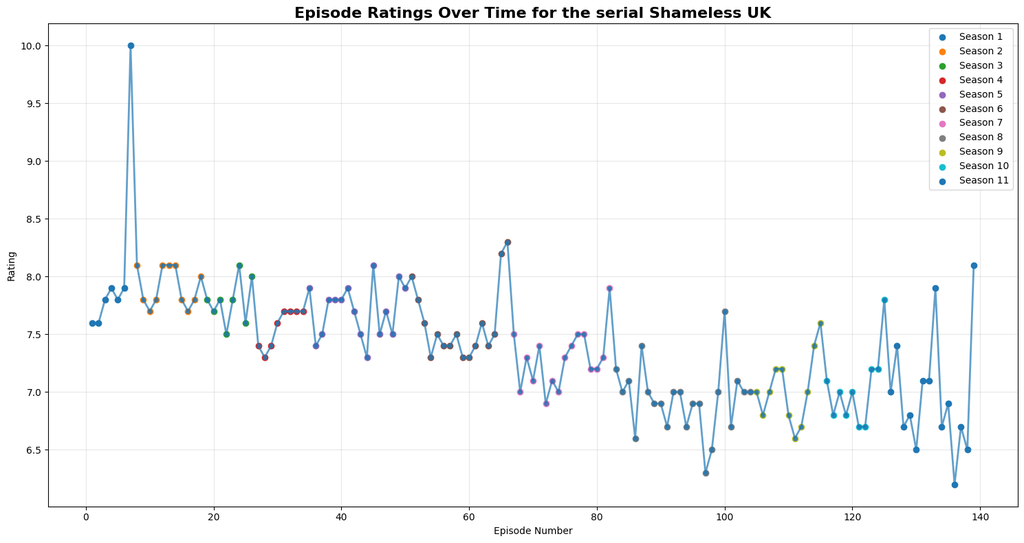

```python
import matplotlib.pyplot as plt

plt.figure(figsize=(15, 8))

# Create episode number for x-axis
df_sorted = shameless_uk_df.sort_values('ReleaseDate').reset_index(drop=True)
df_sorted['Episode_Number'] = range(1, len(df_sorted) + 1)

# Plot ratings over time
plt.plot(df_sorted['Episode_Number'], df_sorted['Rating'], 'o-', alpha=0.7, linewidth=2, markersize=4)
plt.title('Episode Ratings Over Time for the serial Shameless UK', fontsize=16, fontweight='bold')
plt.xlabel('Episode Number')
plt.ylabel('Rating')
plt.grid(True, alpha=0.3)
for season in shameless_uk_df['Season'].unique():
    season_episodes = df_sorted[df_sorted['Season'] == season]
    plt.scatter(season_episodes['Episode_Number'], season_episodes['Rating'],
               label=f'Season {season}')

plt.legend()
plt.tight_layout()
```

This graph shows us that ratings of Shameless UK serial is getting lower and lower with additional season, what means this serial was less popular with each year. The interesting graph, which can be followed there, mostly last episodes were more popular than first one.

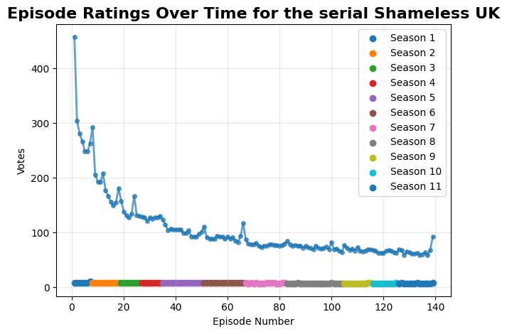

```python
# Plot votes over time
plt.plot(df_sorted['Episode_Number'], df_sorted['Votes'], 'o-', alpha=0.7, linewidth=2, markersize=4)
plt.title('Episode Ratings Over Time for the serial Shameless UK', fontsize=16, fontweight='bold')
plt.xlabel('Episode Number')
plt.ylabel('Votes')
plt.grid(True, alpha=0.3)
for season in shameless_uk_df['Season'].unique():
    season_episodes = df_sorted[df_sorted['Season'] == season]
    plt.scatter(season_episodes['Episode_Number'], season_episodes['Rating'],
               label=f'Season {season}')

plt.legend()
plt.tight_layout()
```

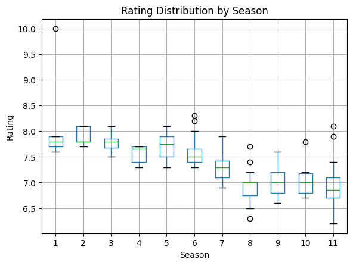

```python
plt.figure(figsize=(10, 6))
shameless_uk_df.boxplot(column='Rating', by='Season')
plt.title('Rating Distribution by Season')
plt.xlabel('Season')
plt.ylabel('Rating')
plt.suptitle('')  # Remove the automatic title
plt.show()
```